# ENV H 504: Data visualization lab

The purpose of this lab is to build familiarity with plotting in R to create figures for grant proposals. This lab walks through building three panels with a map and violin plot on each panel. We’ll use California counties, simulated data, and then packages `geom_sf()` for maps and `geom_violin()` for distributions. We then use `cowplot` to compile our final figure.

## setup: path and packages

we will set the data path here. we use a default `"."` which just means right here. in this lab, this will work well as we generate and use synthetic data that we save in memory. for your own work, you may need to set `data_path` to your folder. here we also choose a palette that matches the palette for the manuscript we were working on – you can use online color palette tools to find a palette that matches your data, such as `metbrewer` or `colorbrewer`.

```r
#------------------------------------------------------------------------------
# data path
data_path <- "."
#------------------------------------------------------------------------------
# cache tigris downloads for faster reruns:
# this is a good idea for repeated runs of the same code so you don't
# have to download the data every time.
options(tigris_use_cache = TRUE)

#------------------------------------------------------------------------------
# packages -- make sure you have pacman installed
library(pacman) # `install.packages("pacman")` if neded
p_load(ggplot2, dplyr, tidyr, sf, tigris, cowplot, scales, lubridate, MetBrewer, viridis)

# Color palette
pal <- met.brewer("Java", n = 3)

# Check that we're using colorblind-friendly colors
colorblind.friendly("Java")
```

```
## [1] TRUE
```

```r
crs <- "EPSG:3310"  # California Albers Equal Area

# Bottom colourbar length: default is much shorter than the map panel; match panel width
# so it lines up with the violins when plots are stacked with cowplot.
map_legend_guide <- guide_colourbar(
  theme = theme(
    legend.key.width  = unit(0.6, "npc"),
    legend.key.height = unit(0.35, "cm")
  )
)
```

## step 1: load spatial data

now we will load California and its counties using `tigris`.

```r
ca_shp <- states(cb = TRUE, year = 2020) %>%
  filter(NAME == "California") %>%
  st_transform(crs)

county_shp <- counties(state = "CA", cb = TRUE, year = 2020) %>%
  rename(county_id = GEOID) %>%
  select(county_id, NAME, geometry) %>%
  st_transform(crs)

# clip state to counties to remove water
ca_shp <- ca_shp %>% st_intersection(county_shp)
```

## step 2: create exposure summary data

now we will create some exposure summary data. we will make plots of the count of days with the exposure. in this case, we are looking at public safety power shutoffs (PSPS) and wildfire smoke. PSPS events are planned power outages to prevent wildfires, however they often do end up co-occurring with wildfire smoke (any estimated wildfire PM<sub>2.5</sub> concentration). here we will visualize how many days each county experienced (1) PSPS event alone, (2) wildfire smoke alone, and (3) both PSPS and wildfire smoke. to do this, we need counts of “exposure-days” by geography and exposure type. here we use **synthetic data** so the lab runs without external files. in practice, you’d load this from your own exposure dataset. we will use `expand_grid()` to create a grid of all possible combinations of county and exposure type, and then use `mutate()` to create the `n_days` column. we keep every county in the grid so maps show the full state (some counties may have zero exposure days).

```r
# synthetic exposure data: county_id, exposure_type, n_days
set.seed(42)
exp_summary <- expand_grid(
  county_id = county_shp$county_id,
  exposure_type = c("PSPS event alone", "WF smoke alone", "WF smoke + PSPS event")
) %>%
  mutate(
    n_days = case_when(
      exposure_type == "PSPS event alone" ~ pmax(0L, as.integer(rnorm(n(), 20, 15))),
      exposure_type == "WF smoke alone"   ~ pmax(0L, as.integer(rnorm(n(), 80, 50))),
      TRUE ~ pmax(0L, as.integer(rnorm(n(), 25, 20)))
    )
  )
  # do not drop rows with n_days == 0: otherwise random zeros remove counties from the map

# join to geometry
exp_sum_shp <- exp_summary %>%
  left_join(county_shp %>% select(county_id, geometry), by = "county_id") %>%
  st_as_sf() %>%
  st_transform(crs)
```

## step 3: a simple map

let’s start with just a simple map of California showing just one of our exposures – wildfire smoke (`filter(exposure_type == "WF smoke alone")`). we will use `geom_sf()` to create our map, and then use `aes(fill = n_days)` to map the variable we want to show (here, `n_days`).

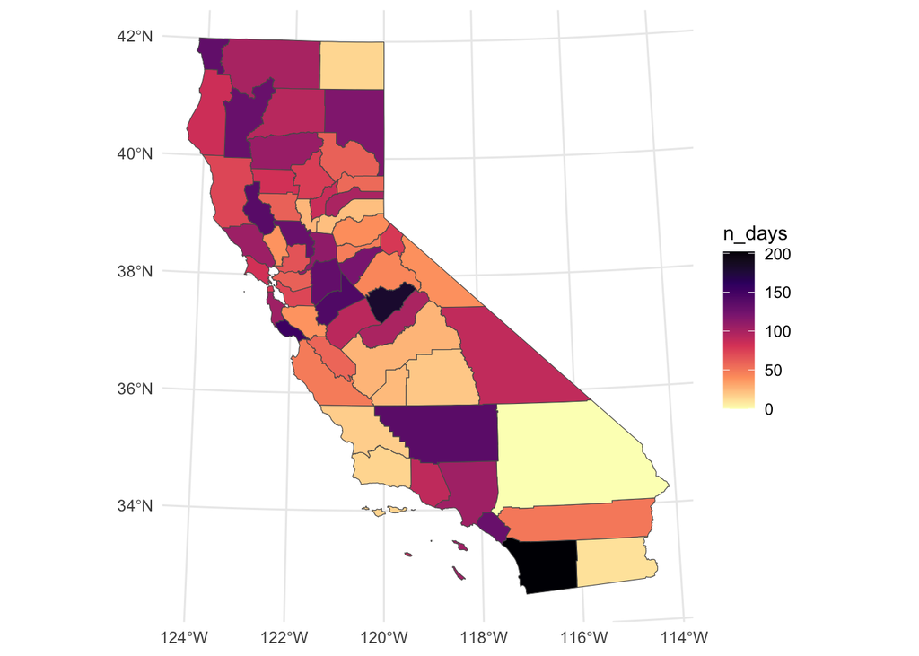

```r
ggplot(exp_sum_shp %>% filter(exposure_type == "WF smoke alone")) +
  geom_sf(aes(fill = n_days)) +
  scale_fill_viridis_c(option = "magma", direction = -1) +
  theme_minimal()
```

now let’s add the county boundaries and a gradient from light to dark. we will use `scale_fill_gradient()` for continuous variables.

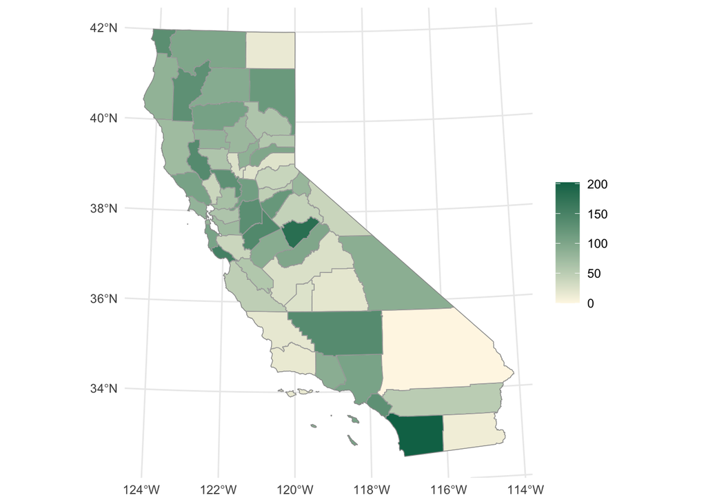

```r
ggplot() +
  geom_sf(data = exp_sum_shp %>% filter(exposure_type == "WF smoke alone"),
          aes(fill = n_days)) +
  geom_sf(data = county_shp, fill = NA, color = alpha("grey", 0.5), linewidth = 0.3) +
  scale_fill_gradient(
    low = "#fef7e6",
    high = pal[3],
    name = NULL,
    labels = comma_format(accuracy = 1)
  ) +
  theme_minimal()
```

## step 5: a simple violin plot

it can be hard to get a sense of the distribution of the days on the map, despite it showing us where the exposure is higher and lower very well. so, let’s add a violin plot to show the distribution of `n_days` under the map. we will use `geom_violin()` with `x = n_days` and a constant `y` to get a horizontal violin. let’s create the violin for only wildfire smoke first (`filter(exposure_type == "WF smoke alone")`).

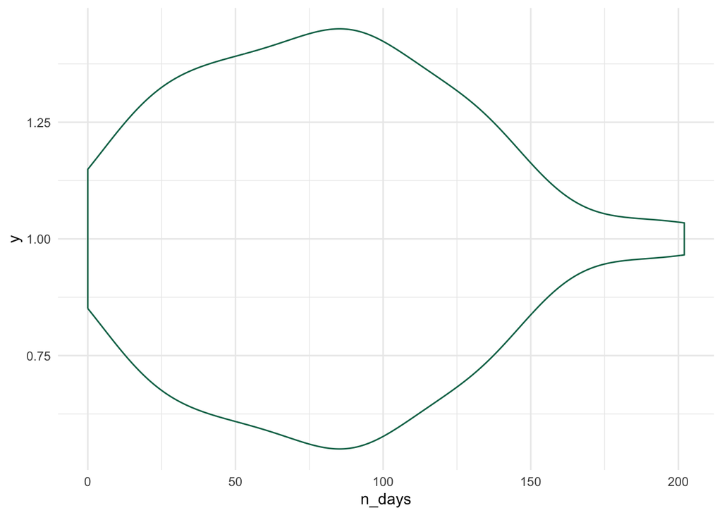

```r
violin_data <- exp_sum_shp %>% filter(exposure_type == "WF smoke alone")

ggplot(violin_data, aes(x = n_days, y = 1)) +
  geom_violin(fill = NA, color = pal[3], linewidth = 0.5) +
  theme_minimal() +
  scale_x_continuous(labels = comma_format(accuracy = 1))
```

## step 6: stack map and violin with cowplot

now let’s stack the map and violin plots vertically using `plot_grid()` from cowplot. we will do this for each of our three panels, but will continue with just wildfire smoke for now (`filter(exposure_type == "WF smoke alone")`). the `rel_heights` argument controls the relative height of each plot. the chunk dimensions match one panel of the final figure so the violin aligns with the map.

NOTE: we use cowplot instead of patchwork because it tends to produce more predictable layouts when combining maps with other plots. you can try this with patchwork and you will see that it can create issues with the layout.

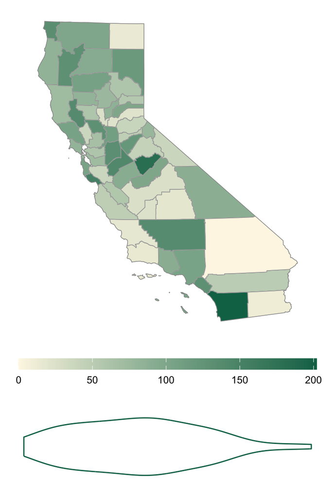

```r
map_plot <- ggplot() +
  geom_sf(data = exp_sum_shp %>% filter(exposure_type == "WF smoke alone"),
          aes(fill = n_days)) +
  geom_sf(data = county_shp, fill = NA, color = alpha("grey", 0.5), linewidth = 0.3) +
  scale_fill_gradient(low = "#fef7e6", high = pal[3], name = NULL,
                     labels = comma_format(accuracy = 1),
                     guide = map_legend_guide) +
  theme_minimal() +
  theme(axis.text = element_blank(), axis.ticks = element_blank(),
        panel.grid = element_blank(), legend.position = "bottom")

violin_plot <- ggplot(violin_data, aes(x = n_days, y = 1)) +
  geom_violin(fill = NA, color = pal[3], linewidth = 0.5) +
  theme_minimal() +
  theme(axis.text = element_blank(), axis.title = element_blank(),
        panel.grid = element_blank(), aspect.ratio = 0.2) +
  scale_x_continuous(labels = comma_format(accuracy = 1))

# stack: map on top, violin below (rel_heights gives map 4x the space of violin)
plot_grid(map_plot, violin_plot, ncol = 1, align = "v", rel_heights = c(4, 1))
```

## step 7: build all three panels and combine

now let’s build all three panels and combine them side by side with `plot_grid()`. the chunk dimensions (12 × 6) ensure violin widths align with maps. we will use a loop to create each panel, and then combine them side by side with `plot_grid()`.

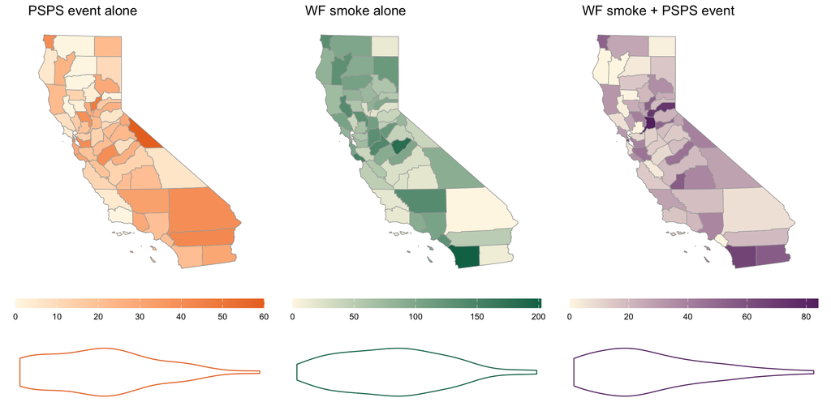

```r
exposure_types <- c("PSPS event alone", "WF smoke alone", "WF smoke + PSPS event")

map_plots <- list()
violin_plots <- list()

for (i in seq_along(exposure_types)) {
  exp_type <- exposure_types[i]
  exp_color <- case_when(
    exp_type == "WF smoke + PSPS event" ~ pal[1],
    exp_type == "PSPS event alone"       ~ pal[2],
    TRUE ~ pal[3]
  )

  exp_data <- exp_sum_shp %>% filter(exposure_type == exp_type)

  map_plots[[i]] <- ggplot() +
    geom_sf(data = exp_data, aes(fill = n_days)) +
    geom_sf(data = county_shp, fill = NA, color = alpha("grey", 0.5), linewidth = 0.3) +
    scale_fill_gradient(low = "#fef7e6", high = exp_color,
                       name = NULL, labels = comma_format(accuracy = 1),
                       guide = map_legend_guide) +
    labs(title = exp_type) +
    theme_minimal() +
    theme(axis.text = element_blank(), axis.ticks = element_blank(),
          panel.grid = element_blank(), plot.title = element_text(size = 14, hjust = 0),
          legend.position = "bottom")

  violin_plots[[i]] <- ggplot(exp_data, aes(x = n_days, y = 1)) +
    geom_violin(fill = NA, color = exp_color, linewidth = 0.5) +
    theme_minimal() +
    theme(axis.text = element_blank(), axis.title = element_blank(),
          panel.grid = element_blank(), aspect.ratio = 0.2,
          plot.margin = margin(0)) +
    scale_x_continuous(labels = comma_format(accuracy = 1))
}

# build each panel: map stacked on violin; then place side by side
panel1 <- plot_grid(map_plots[[1]], violin_plots[[1]], ncol = 1, align = "v", rel_heights = c(4, 1))
panel2 <- plot_grid(map_plots[[2]], violin_plots[[2]], ncol = 1, align = "v", rel_heights = c(4, 1))
panel3 <- plot_grid(map_plots[[3]], violin_plots[[3]], ncol = 1, align = "v", rel_heights = c(4, 1))

combined <- plot_grid(panel1, panel2, panel3, ncol = 3, align = "h", rel_widths = c(1, 1, 1))

combined
```

## step 8: save the figure

```r
# create output folder if needed
ggsave("../output/map_violin_panels.pdf",
       combined, width = 12, height = 6, dpi = 100)
```

## summary

- `geom_sf()` for mapping
- `scale_fill_gradient()` for continuous fill
- `geom_violin()` for distributions
- `cowplot::plot_grid()` to stack and arrange plots (often more reliable than patchwork for complicated map + other-plot combinations)